# Multivariate Regression Examples 3 - Week 3

WHO hunger data.

```r
hunger <-read.csv("hunger.csv")
dim(hunger)
```

```
[1] 948  13
```

```r
names(hunger)
```

```
 [1] "X"              "Indicator"      "Data.Source"    "PUBLISH.STATES" "Year"
 [6] "WHO.region"     "Country"        "Sex"            "Display.Value"  "Numeric"
[11] "Low"            "High"           "Comments"
```

The Numeric column tells us the percentage of children under age 5 who were underweight

### Look at the rate of hunger and see how it’s changed over time

```r
fit = lm(Numeric ~ Year, data = hunger)
summary(fit)$coef
```

```
              Estimate  Std. Error   t value     Pr(>|t|)
(Intercept) 634.479660 121.1445995  5.237375 2.007699e-07
Year         -0.308397   0.0605292 -5.095012 4.209412e-07
```

As time goes on, the rate of hunger decreases. The intercept represents the % of hungry children at year 0.

### Rate of hunger by sex

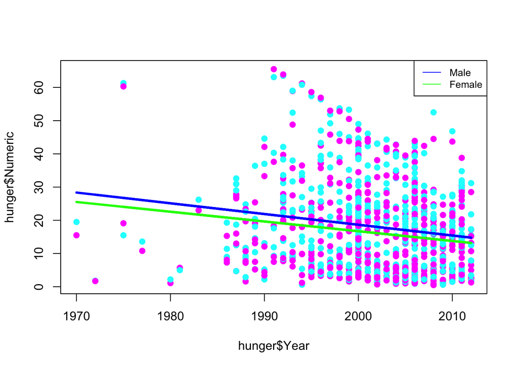

```r
lmF <- lm(Numeric[Sex=="Female"] ~ Year[Sex=="Female"],hunger)
lmM <- lm(Numeric[Sex=="Male"] ~ Year[Sex=="Male"],hunger)

plot(hunger$Year,hunger$Numeric,type="n")
points(hunger$Year,hunger$Numeric,pch=19,col=((hunger$Sex=="Female")*1+125))
lines(hunger$Year[hunger$Sex=="Male"],lmM$fitted,col="blue",lwd=3)
lines(hunger$Year[hunger$Sex=="Female"],lmF$fitted,col="green",lwd=3)
legend("topright", legend=c("Male", "Female"),
       col=c("blue", "green"), lty=c(1,1), cex=0.8)
```

```r
summary(lmM)$coef
```

```
                       Estimate   Std. Error   t value     Pr(>|t|)
(Intercept)         665.4535198 174.50726183  3.813329 0.0001552989
Year[Sex == "Male"]  -0.3233977   0.08719155 -3.709049 0.0002327811
```

```r
lmM$coef[2]
```

```
Year[Sex == "Male"]
         -0.3233977
```

The slopes of the lines are different: around 2010 they are closer together than around 1970. The lines are not parallel, therefore they have different slopes. Both slopes are clearly negative.

### Use gender and year as predictors

```r
lmBoth = lm(Numeric ~ Year + Sex, data = hunger)
summary(lmBoth)
```

```
Call:
lm(formula = Numeric ~ Year + Sex, data = hunger)

Residuals:
    Min      1Q  Median      3Q     Max
-25.472 -11.297  -1.848   7.058  45.990

Coefficients:
            Estimate Std. Error t value Pr(>|t|)
(Intercept) 633.5283   120.8950   5.240 1.98e-07 ***
Year         -0.3084     0.0604  -5.106 3.99e-07 ***
SexMale       1.9027     0.8576   2.219   0.0267 *
---
Signif. codes:  0 '***' 0.001 '**' 0.01 '*' 0.05 '.' 0.1 ' ' 1

Residual standard error: 13.2 on 945 degrees of freedom
Multiple R-squared:  0.03175,   Adjusted R-squared:  0.0297
F-statistic: 15.49 on 2 and 945 DF,  p-value: 2.392e-07
```

Male and Female are categorical variables. R treats the 1st factor as the reference and its estimate is the intercept.

So the intercept shown in the summary represents the percentage of female that were hungry at year 0.

To calculate the percentage of hungry males at year zero it is necessary to add the intercept and the male estimate.

```r
# Percentage of males hungry at year zero
lmBoth$coef[1] + lmBoth$coef[3]
```

```
(Intercept)
    635.431
```

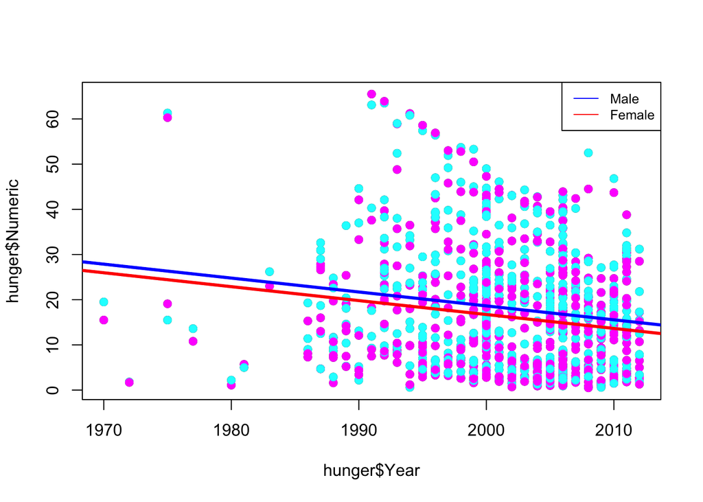

### Interaction between year and gender as predictor

```r
lmInter = lm(Numeric ~ Year+Sex+(Sex*Year), hunger)
summary(lmInter)
```

```
Call:
lm(formula = Numeric ~ Year + Sex + (Sex * Year), data = hunger)

Residuals:
    Min      1Q  Median      3Q     Max
-25.913 -11.248  -1.853   7.087  46.146

Coefficients:
              Estimate Std. Error t value Pr(>|t|)
(Intercept)  603.50580  171.05519   3.528 0.000439 ***
Year          -0.29340    0.08547  -3.433 0.000623 ***
SexMale       61.94772  241.90858   0.256 0.797946
Year:SexMale  -0.03000    0.12087  -0.248 0.804022
---
Signif. codes:  0 '***' 0.001 '**' 0.01 '*' 0.05 '.' 0.1 ' ' 1

Residual standard error: 13.21 on 944 degrees of freedom
Multiple R-squared:  0.03181,   Adjusted R-squared:  0.02874
F-statistic: 10.34 on 3 and 944 DF,  p-value: 1.064e-06
```

```r
# Annual change in % of hungry females
lmInter$coef[2]
```

```
      Year
-0.2933964
```

```r
# Annual change in % of hungry males
lmInter$coef[4] + lmInter$coef[2]
```

```
Year:SexMale
  -0.3233977
```